# Life_Expectancy_Data_analysis

# 3. Use fertility_rate dataset to extract fertility_rate for the most populous countries. Use an appropriate graph to show their trend since 1960-2016

## converting fertility rate data from wide to long data set

```r
fertility_long <- fertility_rate %>%
  pivot_longer(
    cols = `1960`:`2016`,           # All year columns
    names_to = "Year",              # New column to store years
    values_to = "FertilityRate"     # New column to store fertility rate values
  ) %>%
  mutate(Year = as.integer(Year))   # Convert Year column from character to integer
```

## Extracting Country using country code converter

# create a real country list ,since some country are not real country list

```r
fertility_long$country <- countrycode(fertility_long$`Country Code`,
                                          origin = "iso3c",
                                          destination = "country.name")
```

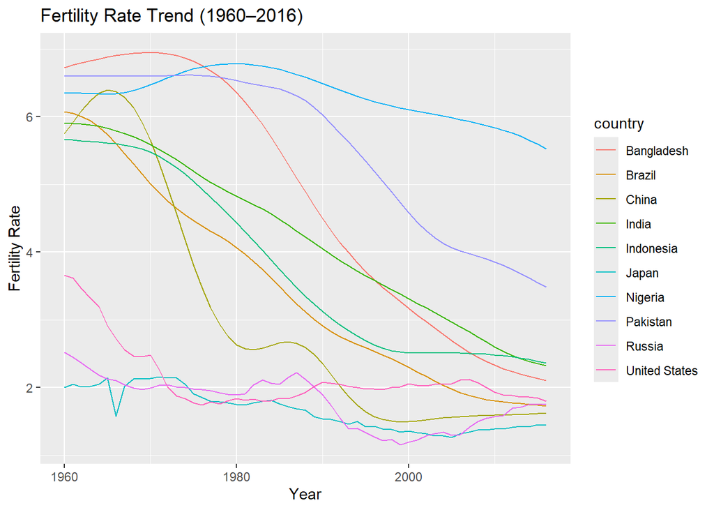

```r
fertility_long_filtered <- fertility_long %>%
  mutate(Year = as.integer(Year)) %>%
  filter(country %in% top10_pop$country & Year >= 1960 & Year <= 2016)

ggplot(fertility_long_filtered, aes(x = Year, y = FertilityRate, color = country)) +
  geom_line() +
  labs(title = "Fertility Rate Trend (1960–2016)", x = "Year", y = "Fertility Rate")
```

## 4. Use life_expectancy dataset to extract life_expectancy for the most populous countries. Use an appropriate graph to show their trend since 1960-2016

## converting fertility rate data from wide to long data set

```r
lifeexpectancy_long <- life_expectancy %>%
  pivot_longer(
    cols = `1960`:`2016`,           # All year columns
    names_to = "Year",              # New column to store years
    values_to = "FertilityRate"     # New column to store fertility rate values
  ) %>%
  mutate(Year = as.integer(Year))   # Convert Year column from character to integer
```

# create a real country list ,since some country are not real country list

```r
lifeexpectancy_long$country <- countrycode(lifeexpectancy_long$`Country Code`,
                                          origin = "iso3c",
                                          destination = "country.name")
```

## Rename FertilityRate

```r
lifeexpectancy_long <- lifeexpectancy_long %>%
  rename(LifeExpectancy = FertilityRate)
```

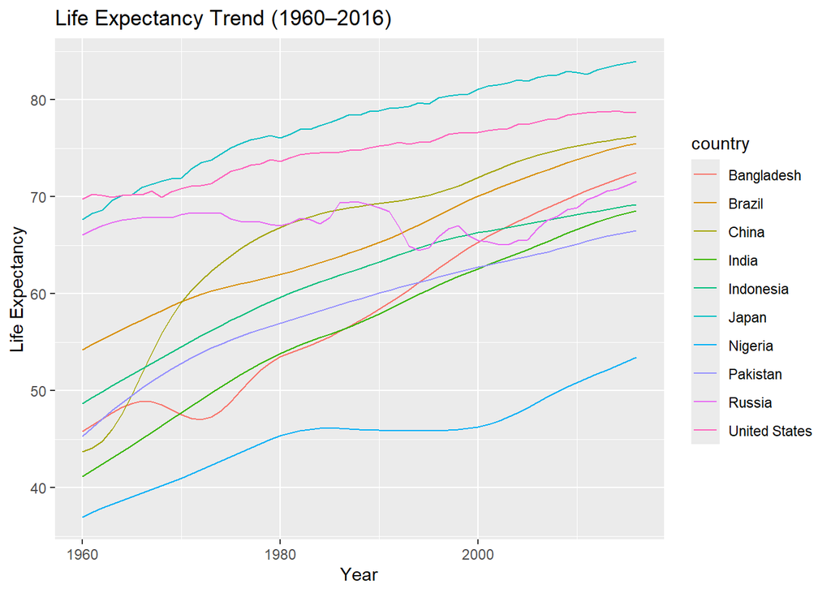

```r
life_expectancy_filtered <- lifeexpectancy_long %>%
  filter(country %in% top10_pop$country & Year >= 1960 & Year <= 2016)

ggplot(life_expectancy_filtered, aes(x = Year, y = LifeExpectancy, color = country)) +
  geom_line() +
  labs(title = "Life Expectancy Trend (1960–2016)", x = "Year", y = "Life Expectancy")
```

## 4.4. Correlation Analysis using life_expectancy_who

#1.Use the life expectancy data dataset to find correlations between Life expectancy , Adult Mortality, infant deaths, Alcohol, percentage expenditure, Hepatitis B, Measles , BMI , under-five deaths , Polio, Total expenditure, Diphtheria , HIV/AIDS, GDP, Population , thinness 1-19 years, thinness 5-9 years, Income composition of resources and Schooling by using both numerical values and heatmap. Interpret the relationship between life expectancy and schooling

```r
str(life_expectancy_data1)
```

```
## tibble [2,938 × 22] (S3: tbl_df/tbl/data.frame)
##  $ Country                        : chr [1:2938] "Afghanistan" "Afghanistan" "Afghanistan" "Afghanistan" ...
##  $ Year                           : num [1:2938] 2015 2014 2013 2012 2011 ...
##  $ Status                         : chr [1:2938] "Developing" "Developing" "Developing" "Developing" ...
##  $ Life expectancy                : num [1:2938] 65 59.9 59.9 59.5 59.2 58.8 58.6 58.1 57.5 57.3 ...
##  $ Adult Mortality                : num [1:2938] 263 271 268 272 275 279 281 287 295 295 ...
##  $ infant deaths                  : num [1:2938] 3 3 3 3 3 3 3 3 3 3 ...
##  $ Alcohol                        : num [1:2938] 0.01 0.01 0.01 0.01 0.01 0.01 0.01 0.03 0.02 0.03 ...
##  $ percentage expenditure         : num [1:2938] 71.3 73.5 73.2 78.2 7.1 ...
##  $ Hepatitis B                    : num [1:2938] 65 87 64 67 68 66 63 64 63 64 ...
##  $ Measles                        : num [1:2938] 17 17 17 17 17 17 17 17 17 17 ...
##  $ BMI                            : num [1:2938] 19.1 18.6 18.1 17.6 17.2 16.7 16.2 15.7 15.2 14.7 ...
##  $ under-five deaths              : num [1:2938] 4 4 4 4 4 4 4 4 4 4 ...
##  $ Polio                          : num [1:2938] 93 93 93 93 93 93 93 93 93 93 ...
##  $ Total expenditure              : num [1:2938] 8.16 8.18 8.13 8.52 7.87 9.2 9.42 8.33 6.73 7.43 ...
##  $ Diphtheria                     : num [1:2938] 93 93 93 93 93 93 93 93 93 93 ...
##  $ HIV/AIDS                       : num [1:2938] 0.1 0.1 0.1 0.1 0.1 0.1 0.1 0.1 0.1 0.1 ...
##  $ GDP                            : num [1:2938] 584.3 612.7 631.7 670 63.5 ...
##  $ Population                     : num [1:2938] 3675929 327582 3675929 3696958 2978599 ...
##  $ thinness  1-19 years           : num [1:2938] 3.4 3.4 3.4 3.4 3.4 3.4 3.4 3.4 3.4 3.4 ...
##  $ thinness 5-9 years             : num [1:2938] 3.4 3.4 3.4 3.4 3.4 3.4 3.4 3.4 3.4 3.4 ...
##  $ Income composition of resources: num [1:2938] 0.479 0.476 0.47 0.463 0.454 0.448 0.434 0.433 0.415 0.405 ...
##  $ Schooling                      : num [1:2938] 10.1 10 9.9 9.8 9.5 9.2 8.9 8.7 8.4 8.1 ...
```

### EDA for new data set / life_expectancy_who

### Checking for duplicates/ rows

```r
sum(duplicated(life_expectancy_data1))
```

```
## [1] 0
```

### Find number of missing values

```r
sum(is.na(life_expectancy_data1))   # In general
```

```
## [1] 0
```

```r
colSums(is.na(life_expectancy_data1)) # per column
```

```
##                         Country                            Year
##                               0                               0
##                          Status                 Life expectancy
##                               0                               0
##                 Adult Mortality                   infant deaths
##                               0                               0
##                         Alcohol          percentage expenditure
##                               0                               0
##                     Hepatitis B                         Measles
##                               0                               0
##                             BMI               under-five deaths
##                               0                               0
##                           Polio               Total expenditure
##                               0                               0
##                      Diphtheria                        HIV/AIDS
##                               0                               0
##                             GDP                      Population
##                               0                               0
##            thinness  1-19 years              thinness 5-9 years
##                               0                               0
## Income composition of resources                       Schooling
##                               0                               0
```

## Normalization of variable names

```r
# pipe the raw dataset through the function clean_names()
life_expectancy_data1 <- life_expectancy_data1 %>%
  janitor::clean_names()

# see the new column names
names(life_expectancy_data1)
```

```
##  [1] "country"                         "year"
##  [3] "status"                          "life_expectancy"
##  [5] "adult_mortality"                 "infant_deaths"
##  [7] "alcohol"                         "percentage_expenditure"
##  [9] "hepatitis_b"                     "measles"
## [11] "bmi"                             "under_five_deaths"
## [13] "polio"                           "total_expenditure"
## [15] "diphtheria"                      "hiv_aids"
## [17] "gdp"                             "population"
## [19] "thinness_1_19_years"             "thinness_5_9_years"
## [21] "income_composition_of_resources" "schooling"
```

```r
# Select only numeric variables of interest
selected_data <- life_expectancy_data1 %>%
  select(life_expectancy,adult_mortality,infant_deaths,alcohol,percentage_expenditure,hepatitis_b,measles,bmi,under_five_deaths,polio,total_expenditure, diphtheria,gdp,population,thinness_1_19_years,thinness_5_9_years,income_composition_of_resources,schooling)
```

```r
# Compute correlation matrix Numerically

cor_matrix <- cor(selected_data )

cor_matrix
```

```
##                                 life_expectancy adult_mortality infant_deaths
## life_expectancy                      1.00000000     -0.58512976   -0.32144790
## adult_mortality                     -0.58512976      1.00000000    0.24040937
## infant_deaths                       -0.32144790      0.24040937    1.00000000
## alcohol                              0.43862120     -0.23115063   -0.26019450
## percentage_expenditure               0.10921054     -0.08391086   -0.12388641
## hepatitis_b                          0.25380817     -0.17286324   -0.16068040
## measles                             -0.05327925      0.04724471    0.09162027
## bmi                                  0.46811339     -0.32970912   -0.22534179
## under_five_deaths                   -0.34825532      0.25514593    0.95020739
## polio                                0.30668626     -0.17626144   -0.18722751
## total_expenditure                    0.26013934     -0.18183318   -0.18721787
## diphtheria                           0.30584345     -0.18708186   -0.19754481
## gdp                                  0.23537866     -0.09881005   -0.05108806
## population                           0.06209374     -0.01744610    0.07253506
## thinness_1_19_years                 -0.49713756      0.31110295    0.22393194
## thinness_5_9_years                  -0.50444612      0.32935666    0.22600688
## income_composition_of_resources      0.73817312     -0.45464590   -0.35196641
## schooling                            0.63374642     -0.36324797   -0.30849077
##                                     alcohol percentage_expenditure  hepatitis_b
## life_expectancy                  0.43862120             0.10921054  0.253808167
## adult_mortality                 -0.23115063            -0.08391086 -0.172863236
## infant_deaths                   -0.26019450            -0.12388641 -0.160680397
## alcohol                          1.00000000             0.06957154  0.097297969
## percentage_expenditure           0.06957154             1.00000000  0.080851624
## hepatitis_b                      0.09729797             0.08085162  1.000000000
## measles                         -0.06036623            -0.04924538 -0.103344355
## bmi                              0.31029609             0.12742238  0.217558925
## under_five_deaths               -0.26599968            -0.13157851 -0.165921596
## polio                            0.20520294             0.06183821  0.482573020
## total_expenditure                0.34798186             0.04421685  0.004843272
## diphtheria                       0.21901758             0.04985710  0.497246707
## gdp                              0.22424538            -0.13426007  0.184629959
## population                      -0.01299237            -0.26708579  0.145924729
## thinness_1_19_years             -0.37978115            -0.08859299 -0.052317736
## thinness_5_9_years              -0.37179146            -0.07832672 -0.061968346
## income_composition_of_resources  0.49125192             0.18571460  0.324741354
## schooling                        0.46300887             0.15593455  0.292299859
##                                     measles         bmi under_five_deaths
## life_expectancy                 -0.05327925  0.46811339       -0.34825532
```

[output cut: 78 more lines]

```
## alcohol                                              0.49125192  0.46300887
## percentage_expenditure                               0.18571460  0.15593455
## hepatitis_b                                          0.32474135  0.29229986
## measles                                             -0.10888163 -0.09691394
## bmi                                                  0.57437469  0.50684783
## under_five_deaths                                   -0.38059758 -0.34229028
## polio                                                0.33116681  0.31971744
## total_expenditure                                    0.21798838  0.27724111
## diphtheria                                           0.33272938  0.31605271
## gdp                                                  0.31718126  0.27333164
## population                                           0.04722707  0.02347906
## thinness_1_19_years                                 -0.50904026 -0.45348541
## thinness_5_9_years                                  -0.50818187 -0.45669152
## income_composition_of_resources                      1.00000000  0.80047481
## schooling                                            0.80047481  1.00000000
```

## 3.Exporting table for VISUALIZATION

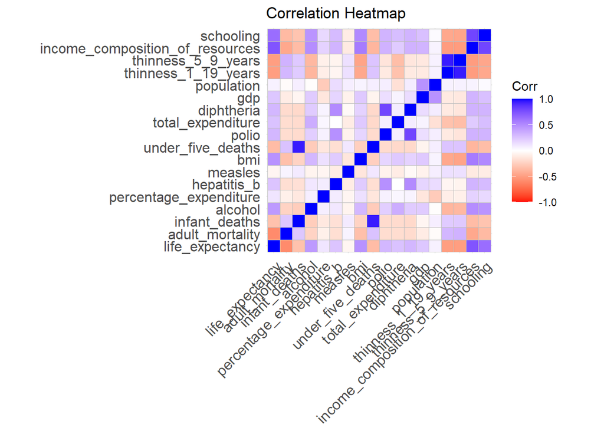

```r
ggcorrplot(cor_matrix,
           method = "square",
           type = "full",
           lab = FALSE,         # shows correlation coefficients/r
           lab_size = 3,
           title = "Correlation Heatmap",
           colors = c("red", "white", "blue"),
           ggtheme = ggplot2::theme_minimal())
```

```r
# Save the heatmap with larger dimensions

ggsave("correlation_heatmap.png",
       plot = last_plot(),
       width = 12, height = 10, dpi = 300)
```

[figure not shown]

```r
ggcorrplot(cor_matrix,
           method = "square",
           type = "full",
           lab = TRUE,         # shows correlation coefficients/r
           lab_size = 3,
           title = "Correlation Heatmap",
           colors = c("red", "white", "blue"),
           ggtheme = ggplot2::theme_minimal())
```

```r
# Save the heatmap with larger dimensions

ggsave("correlation_heatmap.png",
       plot = last_plot(),
       width = 12, height = 10, dpi = 300)
```

## Interpretation

```r
# Correlation between Life Expectancy and Schooling

cor(selected_data$life_expectancy, selected_data$schooling)
```

```
## [1] 0.6337464
```

## Interpretation of life expectancy and schooling

There is a strong positive relationship between life expectancy and schooling (r = + 0.63). This implies that as the level of education increases, people tend to live longer. Education likely improves health awareness, promotes healthy behaviors, and increases access to better jobs and healthcare.

## 2. Create a new variable called fertility rate in the life expectancy data dataset. It should contain values from the fertility_rate dataset, merged on both Country and Year. Using appropriate methods (such as visualization, statistical analysis of numerical values, or regression), determine the pattern of the relationship between life expectancy and fertility rate

```r
# merge them by country and year

# Rename

fertility_long <- fertility_long %>%
  rename(year = Year)


# life_expectancy_data1 , This is life expectancy data data set with details of clinical information


merged_data <- left_join(life_expectancy_data1, fertility_long,
                         by = c("country", "year"))
```

## Relationship between life expectancy and fertility rate

# 1. Use scatter Plot with trendline

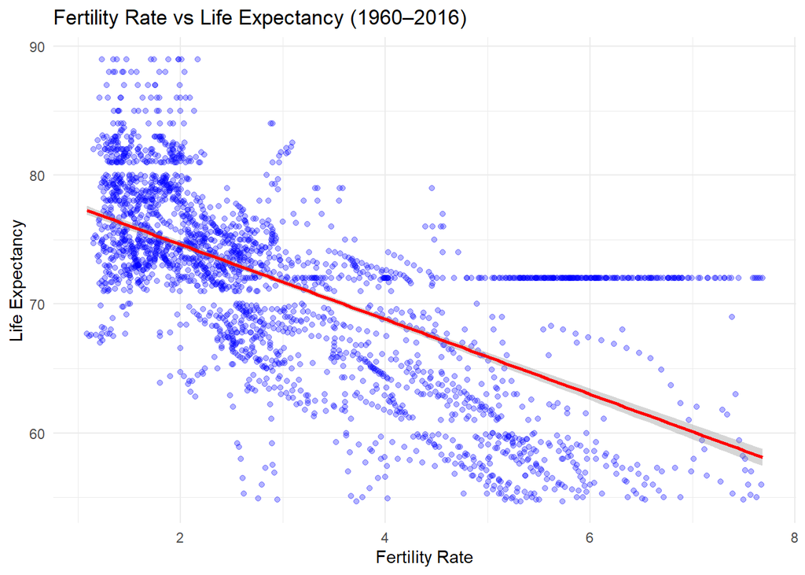

```r
ggplot(merged_data, aes(x = FertilityRate, y = life_expectancy)) +
  geom_point(alpha = 0.3, color = "blue") +
  geom_smooth(method = "lm", se = TRUE, color = "red") +
  labs(title = "Fertility Rate vs Life Expectancy (1960–2016)",
       x = "Fertility Rate",
       y = "Life Expectancy") +
  theme_minimal()
```

# 2. correlation

```r
cor.test(merged_data$FertilityRate, merged_data$life_expectancy)
```

```
##
##  Pearson's product-moment correlation
##
## data:  merged_data$FertilityRate and merged_data$life_expectancy
## t = -42.215, df = 2494, p-value < 2.2e-16
## alternative hypothesis: true correlation is not equal to 0
## 95 percent confidence interval:
##  -0.6678881 -0.6220930
## sample estimates:
##        cor
## -0.6455706
```

## Interpretation

A Pearson’s product-moment correlation was performed to assess the relationship between fertility rate and life expectancy. The results indicated a strong negative correlation:

Correlation coefficient (r): -0.64

Conclusion: This correlation is statistically significant at p-value <0.05 , suggesting that as fertility rates increase, life expectancy tends to decrease, and vice versa.

# 3. Linear Regression

```r
model <- lm(life_expectancy ~ FertilityRate, data = merged_data)
summary(model)
```

```
##
## Call:
## lm(formula = life_expectancy ~ FertilityRate, data = merged_data)
##
## Residuals:
##     Min      1Q  Median      3Q     Max
## -17.520  -3.894  -0.179   3.626  14.876
##
## Coefficients:
##               Estimate Std. Error t value Pr(>|t|)
## (Intercept)   80.43092    0.24105  333.67   <2e-16 ***
## FertilityRate -2.90623    0.06884  -42.22   <2e-16 ***
## ---
## Signif. codes:  0 '***' 0.001 '**' 0.01 '*' 0.05 '.' 0.1 ' ' 1
##
## Residual standard error: 5.538 on 2494 degrees of freedom
##   (442 observations deleted due to missingness)
## Multiple R-squared:  0.4168, Adjusted R-squared:  0.4165
## F-statistic:  1782 on 1 and 2494 DF,  p-value: < 2.2e-16
```

# Interpretation of the linear model

## 3. Using the life expectancy data dataset (from the previous question), drop the Population variable. Assume that Life expectancy is the dependent variable, and the remaining variables are independent variables. Develop a linear regression model and evaluate its performance using the R-squared value and RMSE. What can be done to improve the performance of the linear re gression model?

```r
# Drop 'Population' column and remove rows with missing values

life_data_clean <- life_expectancy_data1[, !(names(life_expectancy_data1) %in% c("population","hiv_aids"))]
life_data_clean <- na.omit(life_data_clean)

life_data_clean$status <- as.factor(life_data_clean$status)
```

## Removed variables due to meaningless variation

HIV/AIDS has no variations. However, we have to remove it in analysis

```r
summary(life_expectancy_data1$hiv_aids)
```

```
##    Min. 1st Qu.  Median    Mean 3rd Qu.    Max.
##     0.1     0.1     0.1     0.1     0.1     0.1
```

## With All non-essential variables to be removed and run final model

```r
life_data_clean1 <- life_expectancy_data1[, !(names(life_expectancy_data1) %in% c("population","country","year","hiv_aids","continent"))]

life_data_clean1 <- na.omit(life_data_clean1)

life_data_clean1$status <- as.factor(life_data_clean1$status)
```

```r
# Fit the model
model1 <- lm(life_expectancy ~ ., data = life_data_clean1)

# View model summary

summary(model1)
```

```
##
## Call:
## lm(formula = life_expectancy ~ ., data = life_data_clean1)
##
## Residuals:
##      Min       1Q   Median       3Q      Max
## -17.9768  -2.1403  -0.0273   2.1431  14.8518
##
## Coefficients:
##                                   Estimate Std. Error t value Pr(>|t|)
## (Intercept)                      5.403e+01  1.510e+00  35.773  < 2e-16 ***
## statusDeveloping                -1.577e+00  2.821e-01  -5.589 2.49e-08 ***
## adult_mortality                 -2.263e-02  9.868e-04 -22.933  < 2e-16 ***
## infant_deaths                    9.602e-02  9.651e-02   0.995  0.31985
## alcohol                          3.855e-02  2.714e-02   1.421  0.15556
## percentage_expenditure          -2.787e-03  1.473e-03  -1.893  0.05848 .
## hepatitis_b                      8.488e-03  1.103e-02   0.770  0.44159
## measles                          1.750e-02  6.195e-03   2.824  0.00477 **
## bmi                             -7.000e-04  4.957e-03  -0.141  0.88772
## under_five_deaths               -1.207e-01  7.501e-02  -1.609  0.10769
## polio                            6.233e-02  2.284e-02   2.729  0.00638 **
## total_expenditure                9.170e-02  4.547e-02   2.017  0.04380 *
## diphtheria                       6.869e-03  2.310e-02   0.297  0.76621
## gdp                              4.347e-05  3.043e-05   1.428  0.15327
## thinness_1_19_years             -1.497e-01  9.190e-02  -1.628  0.10353
## thinness_5_9_years              -1.480e-01  9.167e-02  -1.615  0.10642
## income_composition_of_resources  1.884e+01  1.019e+00  18.488  < 2e-16 ***
## schooling                        2.185e-01  5.499e-02   3.974 7.25e-05 ***
## ---
## Signif. codes:  0 '***' 0.001 '**' 0.01 '*' 0.05 '.' 0.1 ' ' 1
##
## Residual standard error: 4.167 on 2920 degrees of freedom
## Multiple R-squared:  0.6548, Adjusted R-squared:  0.6528
## F-statistic: 325.8 on 17 and 2920 DF,  p-value: < 2.2e-16
```

```r
# R-squared is included in summary
#r_squared <- summary(model)$r.squared

# RMSE calculation
#predictions <- predict(model, newdata = life_data_clean)
#rmse <- sqrt(mean((life_data_clean$life_expectancy - predictions)^2))

# Print metrics
#cat("R-squared:", r_squared, "\n")
#cat("RMSE:", rmse, "\n")
```

## Overall Interpretation of the multiple regression model

🔵 Positive Factors Increasing Life Expectancy Several key factors were found to significantly contribute to higher life expectancy:

1. Access to resources and income equity: Countries where people have better access to basic resources and where income is more evenly distributed tend to have longer life expectancy. This reflects the importance of economic and social stability in supporting health and wellbeing.
2. Education (schooling): Higher levels of education in a population are strongly linked to longer life expectancy. Education likely promotes healthier lifestyles, better healthcare decisions, and increased access to employment and income.
3. Immunization coverage: Greater coverage of vaccines such as polio was associated with improved life expectancy. This highlights the vital role of preventive health measures in reducing disease and prolonging life.
4. Health system investment: Countries that allocate a higher portion of their expenditure to health tend to enjoy better health outcomes and longer life spans. This suggests that investing in healthcare infrastructure and services is essential for population health.
5. Effective disease monitoring and reporting: While measles is a disease with harmful effects, its positive association with life expectancy in this analysis may reflect better disease surveillance and reporting systems typically found in more developed health systems.

🔴 Negative Factors Decreasing Life Expectancy Some factors were found to significantly reduce life expectancy:

1. High adult mortality: A higher death rate among adults strongly lowers the overall life expectancy, indicating poor health conditions or access to care for the working-age population.
2. Developing country status: Countries classified as developing generally have lower life expectancy. This likely results from limited healthcare infrastructure, inadequate access to clean water and sanitation, lower education levels, and other social determinants of health.

# What to do to improve performance of model

1. Feature Engineering: Check for non-linear relationships, Transform skewed variables (e.g., log of GDP).
2. Remove Multicollinearity:
3. Regularization: Try Ridge or Lasso regression (via glmnet package).
4. Outlier Handling: Use diagnostic plots to identify and remove outliers.
5. And, others

## 4.5 Comparing life expectancy by continent

# classify country by contint using valid list of countries

```r
life_expectancy_data1$continent <- countrycode(life_expectancy_data1$country,
                                         origin = "country.name",
                                         destination = "continent")
```

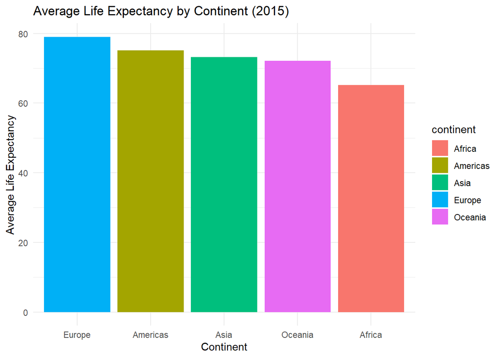

```r
life_2015 <- life_expectancy_data1 %>%
  filter(year == 2015, !is.na(continent), !is.na(life_expectancy)) %>%
  group_by(continent) %>%
  summarise(avg_life_expectancy = mean(life_expectancy, na.rm = TRUE)) %>%
  arrange(desc(avg_life_expectancy))


ggplot(life_2015, aes(x = reorder(continent, -avg_life_expectancy),
                      y = avg_life_expectancy, fill = continent)) +
  geom_col() +
  labs(title = "Average Life Expectancy by Continent (2015)",
       x = "Continent", y = "Average Life Expectancy") +
  theme_minimal()
```

## Which continent has the lowest? What is its average?

```r
life_2015 %>% slice_tail(n = 1)
```

```
## # A tibble: 1 × 2
##   continent avg_life_expectancy
##   <chr>                   <dbl>
## 1 Africa                   65.1
```

## Which continent has the Highest ? What is its average?

```r
life_2015 %>% slice_head(n = 1)
```

```
## # A tibble: 1 × 2
##   continent avg_life_expectancy
##   <chr>                   <dbl>
## 1 Europe                   79.0
```

## 4.6 Comparing life expectancy in EAC and SADC

Extract the life expectancy data for the year 2013 only. Use it to compare the average life expectancy between the East African Community and the Southern African Development Community.

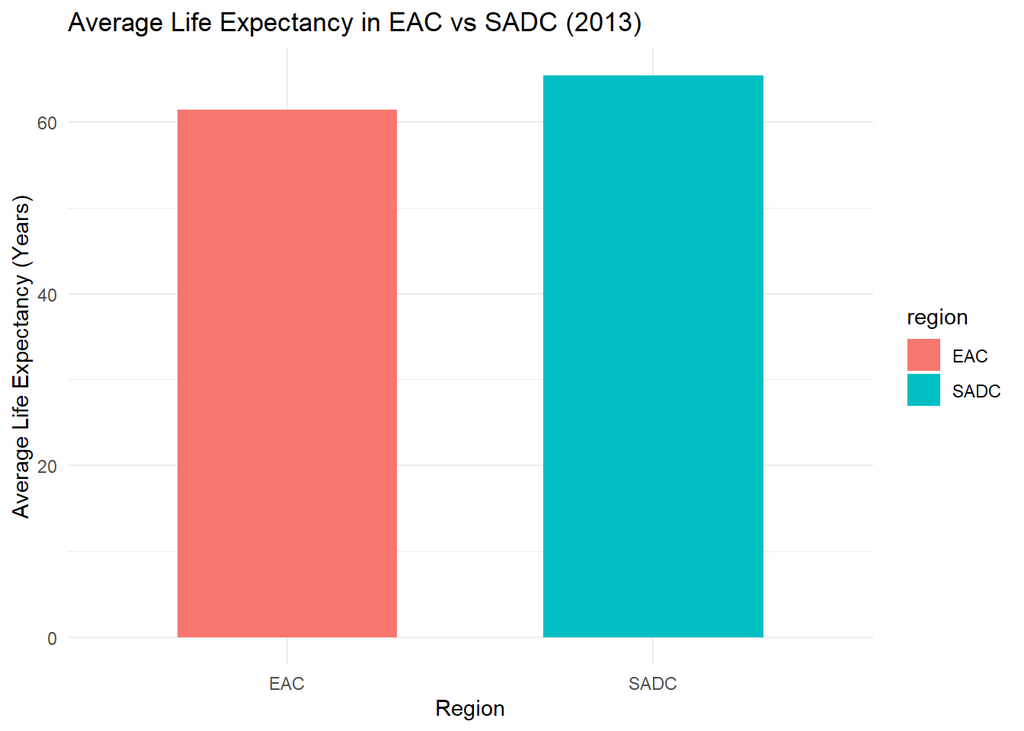

```r
## Define EAC and SADC

EAC_countries <- c("Burundi", "Kenya", "Rwanda", "South Sudan", "Tanzania", "Uganda", "Democratic Republic of the Congo")
SADC_countries <- c("Angola", "Botswana", "Comoros", "Democratic Republic of the Congo", "Eswatini", "Lesotho",
                    "Madagascar", "Malawi", "Mauritius", "Mozambique", "Namibia", "Seychelles", "South Africa",
                    "Tanzania", "Zambia", "Zimbabwe")

## Filter 2013 data and assign regional groups

life_2013 <- life_expectancy_data1 %>%
  filter(year == 2013, !is.na(life_expectancy)) %>%
  mutate(region = case_when(
    country %in% EAC_countries ~ "EAC",
    country %in% SADC_countries ~ "SADC",
    TRUE ~ NA_character_
  )) %>%
  filter(!is.na(region))

## compute average per each region

avg_life_by_region <- life_2013 %>%
  group_by(region) %>%
  summarise(avg_life_expectancy = mean(life_expectancy, na.rm = TRUE))

## Plot for comparison

ggplot(avg_life_by_region, aes(x = region, y = avg_life_expectancy, fill = region)) +
  geom_col(width = 0.6) +
  labs(title = "Average Life Expectancy in EAC vs SADC (2013)",
       x = "Region", y = "Average Life Expectancy (Years)") +
  theme_minimal()
```

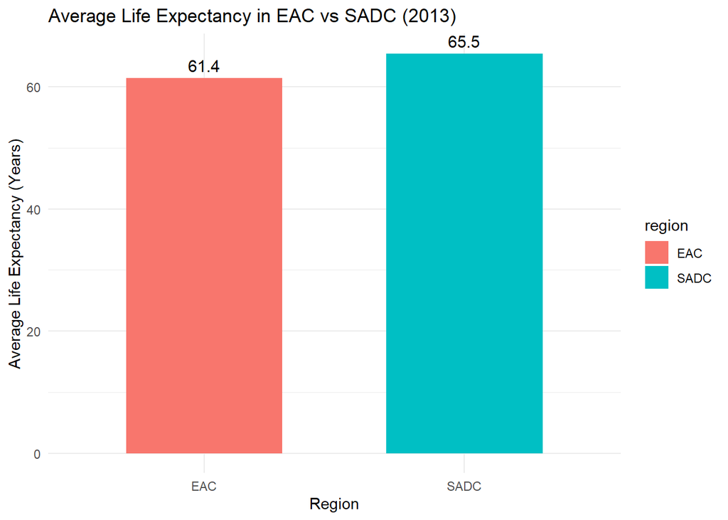

```r
##. speicif value to each


ggplot(avg_life_by_region, aes(x = region, y = avg_life_expectancy, fill = region)) +
  geom_col(width = 0.6) +
  geom_text(aes(label = round(avg_life_expectancy, 1)), vjust = -0.5, size = 4) +
  labs(title = "Average Life Expectancy in EAC vs SADC (2013)",
       x = "Region", y = "Average Life Expectancy (Years)") +
  theme_minimal()
```

Thank you